# Hector Permafrost

Alexey N. Shiklomanov

Ben Bond-Lamberty

Ben Kravitz?

Kate Calvin?

Corinne Hartin

03 June, 2019

Abstract

# Introduction

Climate change is a problem (CITE: IPCC, NCA, etc.). Important to reduce carbon emissions to meet temperature targets. The extent of anthropogenic emissions reduction depends on what how much help (or push-back) we get from the physical and biological Earth systems.

On the other hand, warming and CO2 fertilization may increase vegetation productivity, which could increase soil C storage through enhanced litterfall; the balance of these two processes is uncertain (Jones et al., 2005). Several modeling studies generally predict increases in soil C in high latitudes (Burke et al., 2017; Ito et al., 2016; Qian et al., 2010). However, this increase is dampened by including permafrost C (Burke et al., 2017).

(Previous work on modeling permafrost) (Burke et al., 2017) – JULES and ORCHIDEE, with new permafrost scheme, combined with intermediate complexity climate-ocean model (IMOGEN), to look at climate sensitivity to permafrost C emissions. Models are highly sensitive to representation of soil processes, which can be more important than differences in scenario and/or climate drivers (Burke et al., 2017).

(Paragraph on simple climate models.) Hector (Hartin et al., 2015). However, Hector does not have an explicit representation of permafrost C emissions. In this study, we investigate whether the additional complexity and parametric and structural uncertainty of an explicit representation of permafrost may be warranted in Hector. To do this, we evaluate the sensitivity of climate variables (as predicted by Hector) to several different exogenous scenarios of permafrost C emissions. (TODO Modify this to be about economic impact)

Some more relevant references: - (Zimov, 2006) - (Treat and Frolking, 2013) - (Burke et al., 2017; Drake et al., 2015; Hope and Schaefer, 2015; Kessler, 2017; Kuhry et al., 2010; Lee et al., 2011; Schaefer et al., 2014, 2011; Schuur and Abbott, 2011; Schuur et al., 2015)

# Methods

## Permafrost emissions scenarios

Digitized scenarios from (Schaefer et al., 2011). SiBCASA model predictions of CO2 emissions (permafrost respiration; $R_{pc}$; note – no methane!) through 2300. These results were digitized using WebPlotDigitizer (https://apps.automeris.io/wpd/), and interpolated to annual resolution (using R `stats::spline` function).

Digitized scenarios from (Hope and Schaefer, 2015). CO2 and CH4 emissions from SiBCASA model.

(Schuur et al., 2009) – Estimate 0.8 - 1.1 Pg C yr-1.

Back-of-the-envelope estimates from (Zimov, 2006): - 500 Gt C in loess that could be completely emitted by 2100 (plus other C sources). - 10-40 g C m-3 day-1 off the bat, slowing down to equilibrium (?) rate of 0.5-5 g C m-3 day-1 for several years. Combine with data on permafrost spatial extent, density, etc. to generate estimates (but can back-calculate from 500 Gt C above?)

## Modeling permafrost emissions

Default heterotrophic respiration ($R$) scheme for a pool $p$ (detritus or soil) in Hector:

$$R_{p} = C_p \times f_p \times Q_{10} ^ \frac{T}{10}$$

This is case 1.

Case 2 uses the same formulation, but splits permafrost C into its own “biome”, with its own photosynthesis ($\beta$) and respiration ($Q_{10}$) parameters.

Case 3 extends Case 2 by calculating CO<sub>2</sub> and CH<sub>4</sub> emissions as a fraction of the total respiration, controlled by two new parameters $\alpha$ and $\phi$:

$$R_{p,tot} = C_p \times f_p \times Q_{10} ^ \frac{T}{10}$$

$$R_{p, CH_4} = \alpha R_{p, tot}$$

$$R_{p, CO_2} = (1 - \alpha) ^ \phi R_{p, tot}$$

## Parameter calibration

We used the `BayesianTools` R package (Hartig et al., 2019) for all parameter calibration. The outputs of these calibrations are joint posterior distributions of parameters and their covariances, from which we sample for the sensitivity analysis.

For global parameters, we used the following likelihood:

$$\log(L) = \sum_s Normal(Hector(\beta, Q_{10}, s) | CMIP5(s), \sigma)$$

where $s$ is one of the four representative carbon pathways (RCPs), $CMIP5(s)$ are the CMIP5 global mean outputs for the corresponding variables, and $\sigma$ is the model error (estimated during the fit). We also used the resulting distributions for $\beta$ and $Q_{10}$ for the non-permafrost biome in cases 2 and 3. We feel this is appropriate because the CMIP5 models against which these parameters are calibrated do not include permafrost C feedbacks.

For case 2, we calibrated the permafrost-specific $\beta$ and $Q_{10}$ against various literature sources, including:

- Land surface model simulations (Burke et al., 2017; Hope and Schaefer, 2015; Schaefer et al., 2011).
  - Try to calibrate against NPP and soil respiration if possible
- Literature surveys (Schaefer et al., 2014)
- Warming experiments (Wickland et al., 2006)
- TODO: Others?

Some of these are time series, while others are individual estimates at particular points in time. To give them equal weight in the likelihood, we down-weight the time series likelihoods by the number of time steps.

For the $\alpha$ and $\phi$ parameters in case 3, we looked at the literature on permafrost methane emissions (e.g., Wickland et al., 2006).

## Initial conditions

For case 1, we use the Hector defaults (Hartin et al., 2015).

## Other notes

Frozen carbon residence time (FCRt) from (Burke et al., 2017):

$$FCRt = FCRt0 * exp(-\Delta T / \Gamma) (for \Delta T > 0.2 °C)$$

- $FCRt_0$ (years) reflects the stability of permafrost C (length of time that permafrost C is stable when $\Delta T = 0$)
- $\Gamma$ – decay term (°C); temperature change at which “the number of years taken for all of the old permafrost C to be emitted reduces to 1/e of its initial value”

Other Hector parameters to consider.

| Variable | INI name | Description | Value |
| --- | --- | --- | --- |
| $f_{nv}$ | `f_nppv` | Fraction of NPP C transferred to vegetation | 0.35 |
| $f_{nd}$ | `f_nppd` | Fraction of NPP C transferred to detritus | 0.60 |
| $f_{nd}$ |  | Fraction of NPP C transferred to soil | 0.05 |
| $f_{lv}$ | `f_lucv` | Fraction of LUC change flux from vegetation | 0.10 |
| $f_{ld}$ | `f_lucd` | Fraction of LUC change flux from detritus | 0.01 |
| $f_{ls}$ |  | Fraction of LUC change flux from soil | 0.89 |
| $f_{ds}$ |  | Fraction of detritus C that goes to soil | 0.60 |
| $f_{rd}$ |  | Fraction of respiration C to detritus | 0.25 |
| $f_{rs}$ |  | Fraction of respriation C to soil | 0.02 |

According to (Hartin et al., 2015), these were selected to be “generally consistent with previous simple earth system models (e.g., Meinshausen et al., 2011)”.

[output not shown]

# Results

## Global Hector

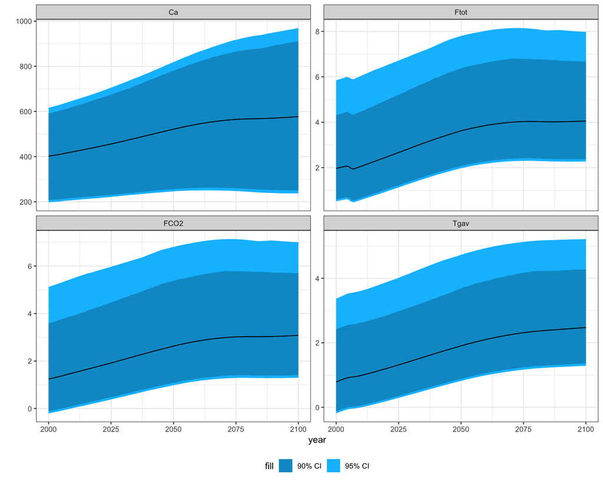

Time series of Hector outputs for different parameter combinations.

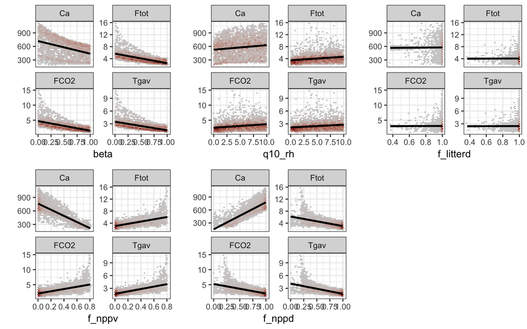

Hector outputs at 2100 as a function of input parameter values.

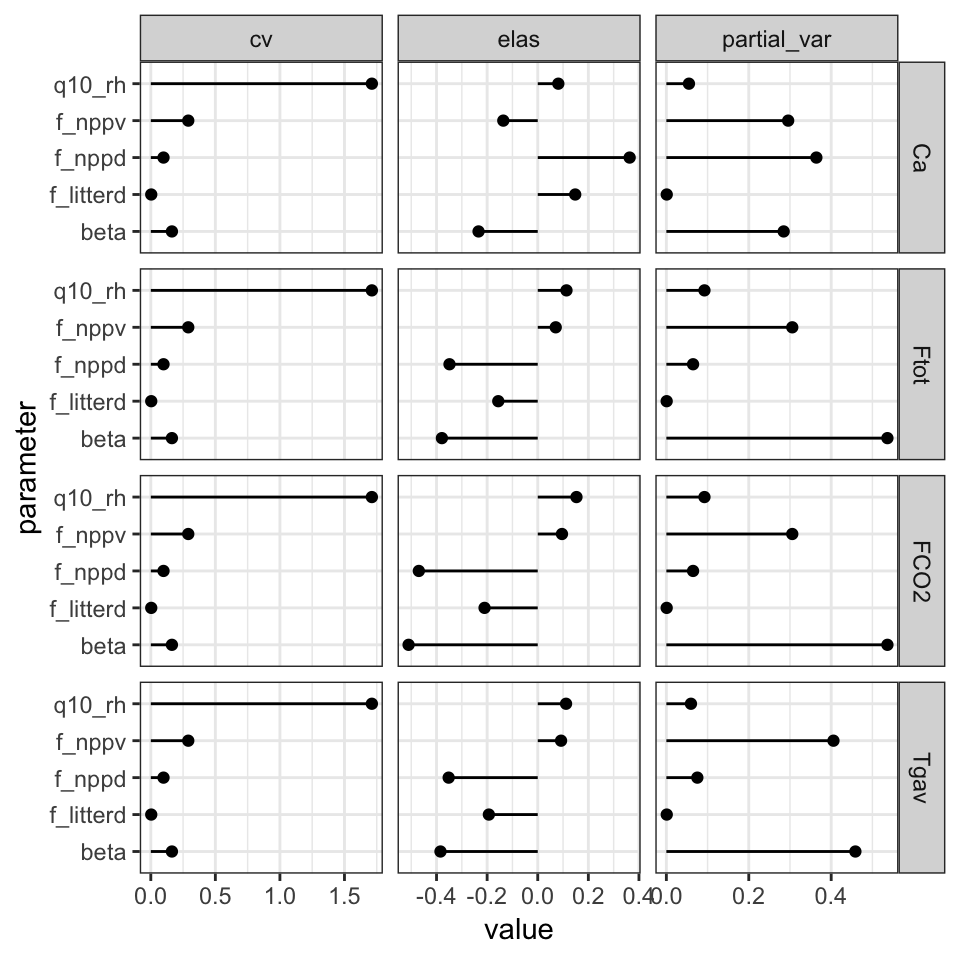

Sensitivity and variance decomposition analysis for global Hector.

## Permafrost as a biome

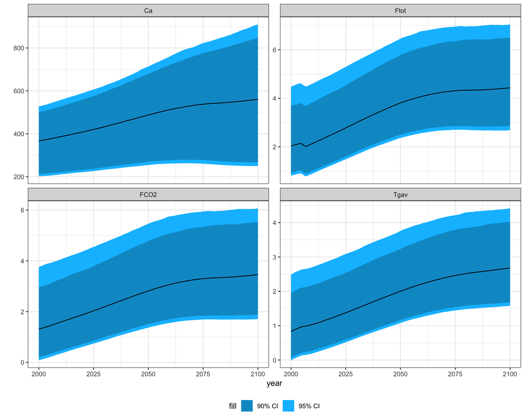

Overall parameter uncertainty of Hector simulations with permafrost biome.

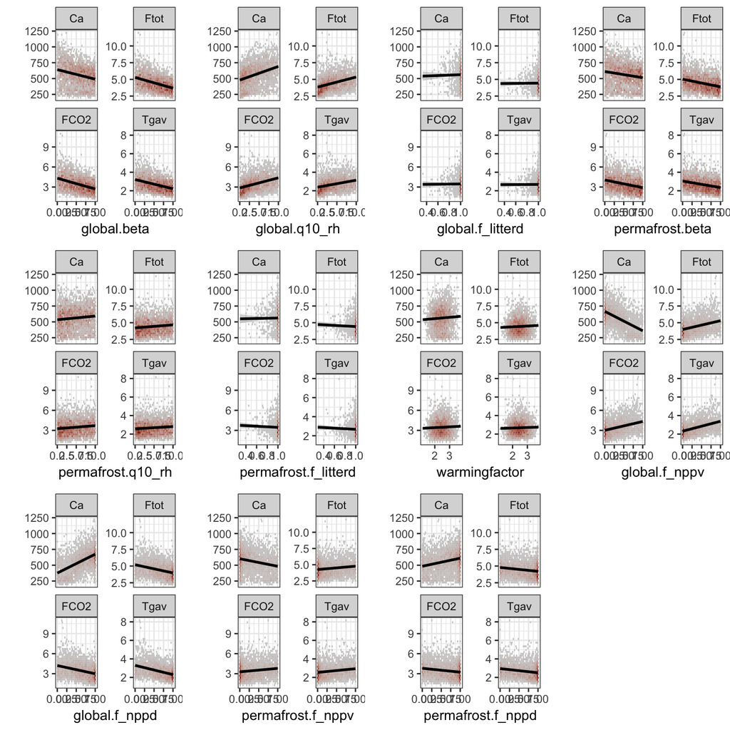

Hector outputs (with permafrost biome) at 2100 as a function of input parameter values.

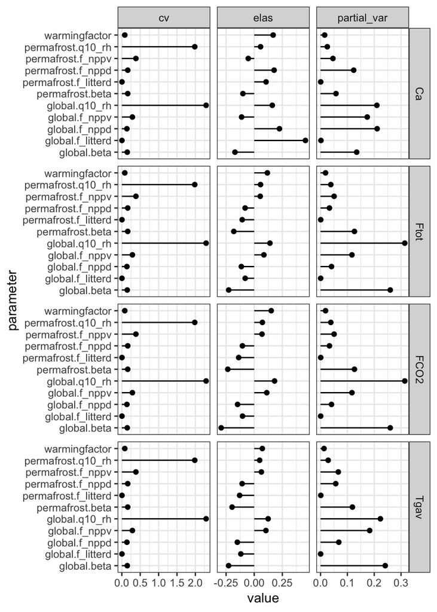

Sensitivity and variance decomposition analysis for Hector with permafrost biome.

# Discussion

Rate of permafrost C release also depends on soil moisture conditions – drier soils release C much faster (“carbon bomb”) than wetter soils (“carbon fizz”) (Elberling et al., 2013). Moisture will also affect the balance of aerobic (CO2 release) vs. anaerobic (CH4) C release (Turetsky et al., 2002), to the extent that unclear if anaerobic (wet) areas are C sources or sinks (Wickland et al., 2006). Effects of permafrost thaw on soil moisture are a complex hydrological problem – drainage very sensitive to local (micro-)topography (Wickland et al., 2006). So will vegetation cover (Wickland et al., 2006).

Temperature amplification of permafrost carbon feedback (by 2100) 0.02 to 0.36 °C (Burke et al., 2013; Schneider von Deimling et al., 2015, 2012), or 0.1 to 0.8 °C in (MacDougall et al., 2012, 2013), or 10-40% of peak temperature change (Crichton et al., 2016), or 0.2 to 12% (Burke et al., 2017).

Permafrost carbon has greater impact at lower emissions scenarios (Burke et al., 2017; MacDougall et al., 2012, 2013) .

# Acknowledgments

# References

Burke, E. J., Jones, C. D. and Koven, C. D.: Estimating the permafrost-carbon climate response in the CMIP5 climate models using a simplified approach, Journal of Climate, 26(14), 4897–4909, doi:10.1175/jcli-d-12-00550.1, 2013.

Burke, E. J., Ekici, A., Huang, Y., Chadburn, S. E., Huntingford, C., Ciais, P., Friedlingstein, P., Peng, S. and Krinner, G.: Quantifying uncertainties of permafrost carbon-climate feedbacks, Biogeosciences Discussions, 1–42, doi:10.5194/bg-2016-544, 2017.

Camill, P., Lynch, J. A., Clark, J. S., Adams, J. B. and Jordan, B.: Changes in biomass, aboveground net primary production, and peat accumulation following permafrost thaw in the boreal peatlands of Manitoba, Canada, Ecosystems, 4(5), 461–478, doi:10.1007/s10021-001-0022-3, 2001.

Chen, Y., Liu, A., Zhang, Z., Hope, C. and Crabbe, M. J. C.: Economic losses of carbon emissions from circum-Arctic permafrost regions under RCP-SSP scenarios, Science of The Total Environment, 658, 1064–1068, doi:10.1016/j.scitotenv.2018.12.299, 2019.

Crichton, K. A., Bouttes, N., Roche, D. M., Chappellaz, J. and Krinner, G.: Permafrost carbon as a missing link to explain CO2 changes during the last deglaciation, Nature Geoscience, 9(9), 683–686, doi:10.1038/ngeo2793, 2016.

Drake, T. W., Wickland, K. P., Spencer, R. G. M., McKnight, D. M. and Striegl, R. G.: Ancient low-molecular-weight organic acids in permafrost fuel rapid carbon dioxide production upon thaw, Proceedings of the National Academy of Sciences, 112(45), 13946–13951, doi:10.1073/pnas.1511705112, 2015.

Elberling, B., Michelsen, A., Schädel, C., Schuur, E. A. G., Christiansen, H. H., Berg, L., Tamstorf, M. P. and Sigsgaard, C.: Long-term CO2 production following permafrost thaw, Nature Climate Change, 3(10), 890–894, doi:10.1038/nclimate1955, 2013.

González-Eguino, M. and Neumann, M. B.: Significant implications of permafrost thawing for climate change control, Climatic Change, 136(2), 381–388, doi:10.1007/s10584-016-1666-5, 2016.

Hartig, F., Minunno, F. and Paul, S.: BayesianTools: General-purpose mcmc and smc samplers and tools for bayesian statistics. [online] Available from: https://CRAN.R-project.org/package=BayesianTools, 2019.

Hartin, C. A., Patel, P., Schwarber, A., Link, R. P. and Bond-Lamberty, B. P.: A simple object-oriented and open-source model for scientific and policy analyses of the global climate system - Hector v1.0, Geoscientific Model Development, 8(4), 939–955, doi:10.5194/gmd-8-939-2015, 2015.

Hartin, C. A., Bond-Lamberty, B., Patel, P. and Mundra, A.: Ocean acidification over the next three centuries using a simple global climate carbon-cycle model: Projections and sensitivities, Biogeosciences, 13(15), 4329–4342, doi:10.5194/bg-13-4329-2016, 2016.

Hope, C. and Schaefer, K.: Economic impacts of carbon dioxide and methane released from thawing permafrost, Nature Climate Change, 6(1), 56–59, doi:10.1038/nclimate2807, 2015.

Ito, A., Nishina, K. and Noda, H. M.: Impacts of future climate change on the carbon budget of northern high-latitude terrestrial ecosystems: An analysis using ISI-MIP data, Polar Science, 10(3), 346–355, doi:10.1016/j.polar.2015.11.002, 2016.

Jones, C., McConnell, C., Coleman, K., Cox, P., Falloon, P., Jenkinson, D. and Powlson, D.: Global climate change and soil carbon stocks; predictions from two contrasting models for the turnover of organic carbon in soil, Global Change Biology, 11(1), 154–166, doi:10.1111/j.1365-2486.2004.00885.x, 2005.

Kessler, L.: Estimating the economic impact of the permafrost carbon feedback, Climate Change Economics, 08(02), 1750008, doi:10.1142/s2010007817500087, 2017.

Kuhry, P., Dorrepaal, E., Hugelius, G., Schuur, E. A. G. and Tarnocai, C.: Potential remobilization of belowground permafrost carbon under future global warming, Permafrost and Periglacial Processes, 21(2), 208–214, doi:10.1002/ppp.684, 2010.

Lawrence, D. M., Slater, A. G. and Swenson, S. C.: Simulation of present-day and future permafrost and seasonally frozen ground conditions in CCSM4, Journal of Climate, 25(7), 2207–2225, doi:10.1175/jcli-d-11-00334.1, 2012.

Lee, H., Schuur, E. A. G., Inglett, K. S., Lavoie, M. and Chanton, J. P.: The rate of permafrost carbon release under aerobic and anaerobic conditions and its potential effects on climate, Global Change Biology, 18(2), 515–527, doi:10.1111/j.1365-2486.2011.02519.x, 2011.

MacDougall, A. H., Avis, C. A. and Weaver, A. J.: Significant contribution to climate warming from the permafrost carbon feedback, Nature Geoscience, 5(10), 719–721, doi:10.1038/ngeo1573, 2012.

MacDougall, A. H., Eby, M. and Weaver, A. J.: If anthropogenic CO2 emissions cease, will atmospheric co2concentration continue to increase?, Journal of Climate, 26(23), 9563–9576, doi:10.1175/jcli-d-12-00751.1, 2013.

Meinshausen, M., Raper, S. C. B. and Wigley, T. M. L.: Emulating coupled atmosphere-ocean and carbon cycle models with a simpler model, magicc6 - part 1: Model description and calibration, Atmospheric Chemistry and Physics, 11(4), 1417–1456, doi:10.5194/acp-11-1417-2011, 2011.

Qian, H., Joseph, R. and Zeng, N.: Enhanced terrestrial carbon uptake in the Northern High Latitudes in the 21st century from the Coupled Carbon Cycle Climate Model Intercomparison Project model projections, Global Change Biology, 16(2), 641–656, doi:10.1111/j.1365-2486.2009.01989.x, 2010.

Schaefer, K., Zhang, T., Bruhwiler, L. and Barrett, A. P.: Amount and timing of permafrost carbon release in response to climate warming, Tellus B, 63(2), 165–180, doi:10.1111/j.1600-0889.2011.00527.x, 2011.

Schaefer, K., Lantuit, H., Romanovsky, V. E., Schuur, E. A. G. and Witt, R.: The impact of the permafrost carbon feedback on global climate, Environmental Research Letters, 9(8), 085003, doi:10.1088/1748-9326/9/8/085003, 2014.

Schneider von Deimling, T., Meinshausen, M., Levermann, A., Huber, V., Frieler, K., Lawrence, D. M. and Brovkin, V.: Estimating the near-surface permafrost-carbon feedback on global warming, Biogeosciences, 9(2), 649–665, doi:10.5194/bg-9-649-2012, 2012.

Schneider von Deimling, T., Grosse, G., Strauss, J., Schirrmeister, L., Morgenstern, A., Schaphoff, S., Meinshausen, M. and Boike, J.: Observation-based modelling of permafrost carbon fluxes with accounting for deep carbon deposits and thermokarst activity, Biogeosciences, 12(11), 3469–3488, doi:10.5194/bg-12-3469-2015, 2015.

Schuur, E. A. G. and Abbott, B.: Climate change: High risk of permafrost thaw, Nature, 480(7375), 32–33, doi:10.1038/480032a, 2011.

Schuur, E. A. G., Vogel, J. G., Crummer, K. G., Lee, H., Sickman, J. O. and Osterkamp, T. E.: The effect of permafrost thaw on old carbon release and net carbon exchange from tundra, Nature, 459(7246), 556–559, doi:10.1038/nature08031, 2009.

Schuur, E. A. G., McGuire, A. D., Schädel, C., Grosse, G., Harden, J. W., Hayes, D. J., Hugelius, G., Koven, C. D., Kuhry, P., Lawrence, D. M. and et al.: Climate change and the permafrost carbon feedback, Nature, 520(7546), 171–179, doi:10.1038/nature14338, 2015.

Tarnocai, C., Canadell, J. G., Schuur, E. A. G., Kuhry, P., Mazhitova, G. and Zimov, S.: Soil organic carbon pools in the northern circumpolar permafrost region, Global Biogeochemical Cycles, 23(2), n/a–n/a, doi:10.1029/2008gb003327, 2009.

Treat, C. C. and Frolking, S.: A permafrost carbon bomb?, Nature Climate Change, 3(10), 865–867, doi:10.1038/nclimate2010, 2013.

Turetsky, M. R., Wieder, R. and Vitt, D. H.: Boreal peatland C fluxes under varying permafrost regimes, Soil Biology and Biochemistry, 34(7), 907–912, doi:10.1016/s0038-0717(02)00022-6, 2002.

Wickland, K. P., Striegl, R. G., Neff, J. C. and Sachs, T.: Effects of permafrost melting on CO2 and CH4 exchange of a poorly drained black spruce lowland, Journal of Geophysical Research: Biogeosciences, 111(G2), n/a–n/a, doi:10.1029/2005jg000099, 2006.

Zimov, S. A.: Climate change: Permafrost and the global carbon budget, Science, 312(5780), 1612–1613, doi:10.1126/science.1128908, 2006.

### Colophon

The current Git commit details are:

```
#> Local:    master /Users/shik544/Box Sync/Projects/hector_project/permafrost_emit
#> Head:     [eb675c5] 2019-06-03: Submit Hector runs separate from workflow
```